# Introductory Statistics with Randomization and Simulation: Chapter 3

## 2009 Iran Election

There was lots of talk of election fraud in the 2009 Iran election. We'll compare the data from a poll conducted before the election (observed data) to the reported votes in the election to see if the two follow the same distribution.

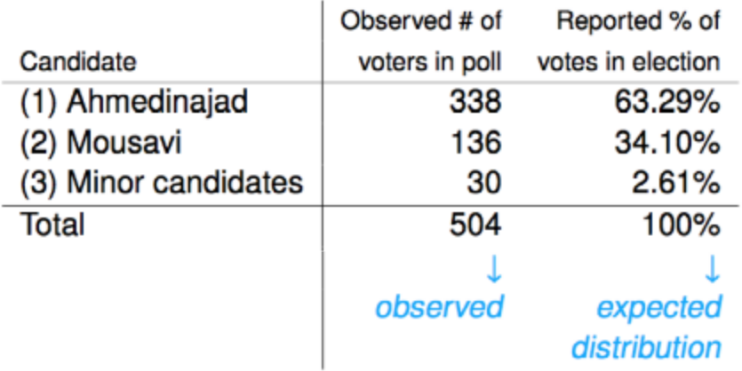

## Hypotheses

What are the hypotheses if the distributions of reported and polled votes are different?

## Hypotheses

What are the hypotheses if the distributions of reported and polled votes are different?

\(H_0\): The observed counts from the poll follow the same distribution as the reported votes.

\(H_A\): The observed counts from the poll do not follow the same distribution as the reported votes.

## Calculation of the test statistic

## Calculation of the test statistic

\[ \begin{split} \frac{(O_1 - E_1)^2}{E_1} = \frac{(338-319)^2}{319} = 1.13 \\ \end{split} \]

## Calculation of the test statistic

\[ \begin{split} \frac{(O_1 - E_1)^2}{E_1} = \frac{(338-319)^2}{319} = 1.13 \\ \frac{(O_2 - E_2)^2}{E_2} = \frac{(136-172)^2}{172} = 7.53 \\ \end{split} \]

## Calculation of the test statistic

\[ \begin{split} \frac{(O_1 - E_1)^2}{E_1} = \frac{(338-319)^2}{319} = 1.13 \\ \frac{(O_2 - E_2)^2}{E_2} = \frac{(136-172)^2}{172} = 7.53 \\ \frac{(O_3 - E_3)^2}{E_3} = \frac{(30-13)^2}{13} = 22.23 \\ \end{split} \]

## Calculation of the test statistic

Then: \[ \chi^2_{3-1=2} = 1.13 + 7.53 + 22.23 = 30.89 \]

So what is the *p*-value?

```r
pchisq(q = 30.89, df = 2, lower.tail = FALSE)
```

```
## [1] 1.960296e-07
```

## Conclusion

Based on these calculations, what is the conclusion of the hypothesis test?

1. *p*-value is low, \(H_0\) is rejected. The observed counts from the poll do not follow the same distribution as the reported votes.
2. *p*-value is high, \(H_0\) is not rejected. The observed counts from the poll follow the same distribution as the reported votes.
3. *p*-value is low, \(H_0\) is rejected. The observed counts from the poll follow the same distribution as the reported votes
4. *p*-value is low, \(H_0\) is not rejected. The observed counts from the poll do not follow the same distribution as the reported votes.

## Conclusion

Based on these calculations, what is the conclusion of the hypothesis test?

1. *p*-value is low, \(H_0\) is rejected. The observed counts from the poll do not follow the same distribution as the reported votes.
2. *p*-value is high, \(H_0\) is not rejected. The observed counts from the poll follow the same distribution as the reported votes.
3. *p*-value is low, \(H_0\) is rejected. The observed counts from the poll follow the same distribution as the reported votes
4. *p*-value is low, \(H_0\) is not rejected. The observed counts from the poll do not follow the same distribution as the reported votes.

## Chi-Square (\(\chi^2\)) Test of Independence

## Popular Kids

In the dataset popular, students in grade 4-6 were asked whether good grades, athletic ability, or popularity was most important to them. A two-way table separating students by grade and by choice of their most important factor is shown below. Do these data provide evidence to suggest that goals vary by grade?

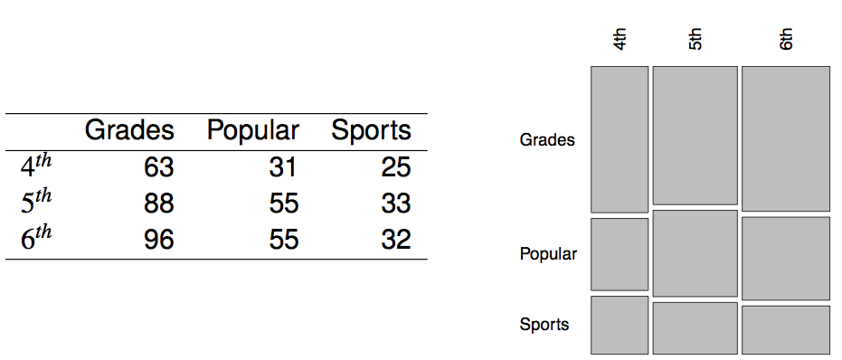

## Chi-square test of independence

- The hypotheses are:
  - \(H_0\): grade and goals are independent. Goals do not vary by grade.
  - \(H_A\): grade and goals are dependent. Goals vary by grade.

## Chi-square test of independence

- The hypotheses are:
  - \(H_0\): grade and goals are independent. Goals do not vary by grade.
  - \(H_A\): grade and goals are dependent. Goals vary by grade.
- The test statistic is calculated as \[ \chi^2_{df} = \sum_{i=1}^{k} \frac{(O_i-E_i)^2}{E_i} \; \text{where} \; df = (R-1) \cdot (C-1) \] with \(k\) the number of total cells, \(R\) the number of rows, and \(C\) the number of columns.

## Notes

- We calculate the **degrees of freedom**, \(df\), differently for one- and two-way tables.
- The *p*-value for this hypothesis test is again the area under the null distribution (in this case, a \(\chi^2_{df}\)), to the right of the calculated test statistic.

## So what are \(O_i\) and \(E_i\)?

The terms of the summation are \(O_i\) and \(E_i\). These are the **observed** and **expected** values of each cell of the table. The observed is easy: it's what is listed in the table!

The **expected** takes a bit of work. We have a formula again: \[ E_i = \frac{(\text{row total}) \cdot (\text{column total})}{\text{table total}}. \]

## The expected quantities

We compute:

- \(E_{\text{row 1, col 1}} = \frac{119 \cdot 247}{478} = 61\).

## The expected quantities

We compute:

- \(E_{\text{row 1, col 1}} = \frac{119 \cdot 247}{478} = 61\).
- \(E_{\text{row 1, col 2}} = \frac{119 \cdot 141}{478} = 35\).

## Practice

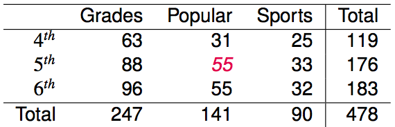

What is the expected count, \(E_{\text{row 2, col 2}}\) for the highlighted (in red) cell?

1. \(\frac{176 \cdot 141}{478}\)
2. \(\frac{119 \cdot 141}{478}\)
3. \(\frac{176 \cdot 247}{478}\)
4. \(\frac{176 \cdot 478}{478}\)

## Practice

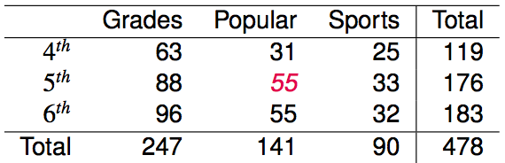

What is the expected count, \(E_{\text{row 2, col 2}}\) for the highlighted (in red) cell?

1. \(\frac{176 \cdot 141}{478} = 52\)
2. \(\frac{119 \cdot 141}{478}\)
3. \(\frac{176 \cdot 247}{478}\)
4. \(\frac{176 \cdot 478}{478}\)

## Calculating the test statistic

Go through each cell of the table, and compute the expected value for that cell using the formula from the previous slides.

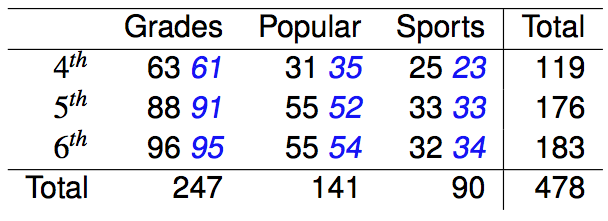

## Calculating the test statistic

Go through each cell of the table, and compute the expected value for that cell using the formula from the previous slides.

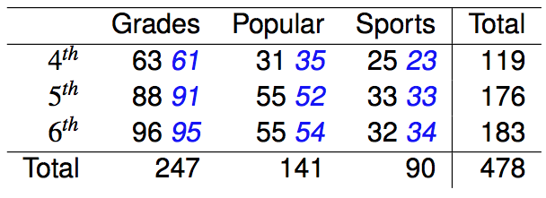

Then compute the test statistic: \[ \begin{split} \chi^2_{df} &= \frac{(63-61)^2}{61} + \frac{(31-35)^2}{35} + \cdots + \frac{(32-34)^2}{34} = 1.3121.\\ df &= (R-1) \cdot (C-1) = (3-1) \cdot (3-1) = 2 \cdot 2 = 4. \end{split} \]

## Finding the *p*-value

Just as in the previous examples of *p*-values, there are two easy ways to find a *p*-value for a \(\chi^2\) test:

- Use R, or other software packages
- Use a table (back of the book, or internet)

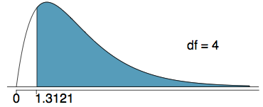

(this is what a \(\chi^2\) distribution looks like)

## Finding the *p*-value

**Method 1**: use R

```r
pchisq(q = 1.3121, df = 4, lower.tail = FALSE)
```

```
## [1] 0.8593193
```

Since this *p*-value is (very!) not small, we do not have evidence to reject the null hypothesis, so we cannot conclude that goals vary by grade.

## Practice

1. More than 0.3
2. Between 0.3 and 0.2
3. Between 0.2 and 0.1
4. Between 0.1 and 0.05
5. Less than 0.001

## Practice

1. More than 0.3
2. Between 0.3 and 0.2
3. Between 0.2 and 0.1
4. Between 0.1 and 0.05
5. Less than 0.001

## Conclusion

What does the data suggest about goals and grade-level? Remember:

- \(H_0\): grade and goals are independent. Goals do not vary by grade.
- \(H_A\): grade and goals are dependent. Goals vary by grade.

Since we have *p*>0.3, we do not have a small *p*, and we cannot reject the null. Thus, we fail to reject the null hypothesis: the data do not provide convincing evidence that grade and goals are dependent. It does not appear that goals vary by grade.

## Tests for Two Categorical Variables

There are **two** tests which can be used to determine whether two categorical variables are related.

Which test you use depends on **how** the data were **collected**. Both methods use two-way tables, and are conducted in similar ways.

## Tests for Two Categorical Variables

The two tests are called the **Test of Homogeneity** (Test of Sameness) and the **Test of Independence**.

- The Test for Homogeneity collects two (or more) **independent** samples from multiple populations
  - each object is assigned a categorical value which keeps track of which group it is from
  - each object is then measured with respect to a different, second, categorical variable
- The Test for Independence collects **one** sample
  - each object in the sample is measured with respect to **two** categorical response variables

## Examples

- If we collect a large sample of people, and record their marital status and income …
- If we collect a random sample of male and female opinions on global warming
- If we conduct a large survey on undergraduate students at Trent …
- If we conduct a large survey on undergraduate students in Ontario …
- If we conduct a large survey on undergraduate students in Ontario, by conducting a number of smaller surveys at each university in Ontario …

## Similarities in the Two Approaches

- In both situations we are interested in knowing whether the two categorical variables are related or unrelated
- Both tests use the same \(\chi^2\) test statistic, formula, and \(p\)-value method
- The **difference** is in the hypotheses and interpretation/conclusion

## Example: GSS

The General Social Survey asked Canadian adults: “There are always some people whose ideas are considered bad or dangerous by other people. For instance, somebody who is against churches and religion. If such a person wanted to make a speech in your (city/town/community) against churches and religion, should he be allowed to speak, or not?” Respondents were also asked about their income, and categorized into four income levels (in $thousands). The responses for these two questions are summarized in the two‐way table below:

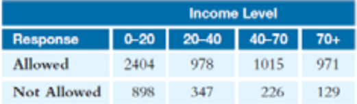

## Example: Obesity

A study reported in the medical journal Obesity analyzed data from the National Longitudinal Study of Adolescent Health. Obesity was defined as having a body mass index (BMI) of 30 or more. The research subjects were followed from adolescence to adulthood, and all the people in the sample were categorized in terms of whether they were obese and whether they were dating, cohabiting, or married. What frequencies should we expect if these variables are not related to each other?

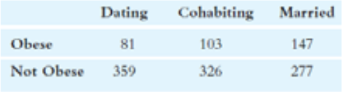

## Example: Polling

A polling organization asks a random sample of people for their party preference (Liberal, Conservative, NDP, Green, or other) and whether they think the minimum wage should be raised, and the organization wanted to test whether party preference and opinion on minimum wage are related.

## Example: Surgery

A large number of surgery patients get infections after surgery, which can sometimes be quite serious. Researchers randomly assigned some surgery patients to receive a simple antibiotic ointment after surgery, others to receive a placebo, and still others to receive just cleansing with soap. We want to test the relationship between treatment and whether or not patients get an infection after surgery.

## Tests of Homogeneity and Independence (both!)

- **Hypotheses**:
  - \(H_0\): there is no relationship between the two variables
  - \(H_A\): there is a relationship between the two variables
- **Requirements**
  - Random samples (independent observations)
  - large samples (expected frequencies \(\geq 5\))

If we have this setup, then the \(\chi^2\) test statistic follows a \(\chi^2\) distribution with \((R-1)\cdot(C-1)\) degrees of freedom.

## Example: GSS (different data)

|  | HS | Clg | Uni | Grad |
| --- | --- | --- | --- | --- |
| Married | 104 | 156 | 110 | 117 |
| Common-Law | 23 | 32 | 30 | 19 |
| Divorced | 76 | 0 | 0 | 0 |
| Widowed | 28 | 10 | 3 | 3 |
| Single | 171 | 29 | 6 | 8 |

## Example: GSS

We can do this analysis in R.

```r
Educ <- matrix(data = c(104, 156, 110, 117, 23, 32, 30, 19, 76, 0, 0, 0, 28, 10, 3, 3,
                        171, 29, 6, 8),
               nrow = 5, ncol = 4, byrow = TRUE)
chisq.test(Educ)
```

```
##
##  Pearson's Chi-squared test
##
## data:  Educ
## X-squared = 349.29, df = 12, p-value < 2.2e-16
```

This is a single sample with two measurements per object (person), so we are performing a \(\chi^2\) Test of Independence. Our \(p\)-value is extremely small, so we reject the null.

## Example: GSS

- The \(\chi^2_\text{test} = 349.29\)
- The \(p\)-value is \(p < 0.00001\)

The conclusion is then that we do have evidence, at a \(\alpha = 0.01\) level, to reject the null hypothesis, and conclude that there is a relationship between marital status and highest educational level completed.

## Drawbacks of the \(\chi^2\) Test

The \(\chi^2\) test reveals only whether two variables **are** related, but not what that relationship is.

If both categorical variables only have two categories (a \(2\times 2\) two-way table), the data can be analyzed using a two-proportion \(z\) test instead, which gives more information (we can setup one-tailed tests specifically).

## Vaccination and Autism

Does the MMR (measles, mumps, rubella) vaccine cause ASD (autism spectrum disorder) in children? The data in the two‐way table are from a study that investigated when ASD symptoms began in a child, and if their onset is related to when the child received the MMR vaccine. Children in the study had experienced a gastrointestinal (GI) event, which is a common side effect of the MMR vaccine.

| Timing of Vaccination | Developed ASD | Did Not Develop ASD |
| --- | --- | --- |
| Received MMR before GI | 12 | 3 |
| Received MMR after GI | 13 | 10 |

## Vaccination and Autism (ctd.)

We want to determine if there is a connection (relationship) between receiving the MMR vaccine and the onset of ASD symptoms.

We can test:

- \(H_0\): the onset of ASD symptoms is independent of when the child receives the MMR vaccine
- \(H_A\): the onset of ASD symptoms is related to when the child receives the MMR vaccine

## Vaccination and Autism (ctd.)

The results of the test are:

```r
mmr <- matrix(data = c(12, 3, 13, 10), nrow = 2, ncol = 2, byrow = TRUE)
chisq.test(mmr)
```

```
##
##  Pearson's Chi-squared test with Yates' continuity correction
##
## data:  mmr
## X-squared = 1.3028, df = 1, p-value = 0.2537
```

From this, we **fail to reject \(H_0\)**, so we conclude that the timing of the MMR vaccine and the onset of ASD symptoms are not related.

## Vaccination and Autism (ctd.)

[figure not shown]

https://academic.oup.com/cid/article/48/4/456/284219

## Vaccination and Autism (ctd.)

[figure not shown]

https://www.smbc-comics.com/comic/autism-and-vaccines